# Making the engine burn fuel

We’ve given the Stirling engine its own inventory slot, and it takes nothing but fuel.

All that’s left is to connect the pieces with some coding glue to consume a piece of fuel and tie the engine’s functionality into its fuel consumption.

When the engine’s inventory slot detects a new item, it should:

1. Tells the `GUIComponent` to emit the `gui_status_changed` signal.
2. When that happens, we trigger the consumption of fuel.
3. We put some amount of chemical energy into the tank, and the pistons can produce power.

After some time, based on what we’re burning, that energy runs out. When it reaches 0, we check if there’s still something in the inventory.

If not, then we shut down the engine. Otherwise, we burn another item and repeat the process.

## Preparing to work

We put everything in `_ready()` to test the power system, but now that its functionality is fuel-bound, we’ll extract the code into functions.

We’ll make most of the work happen in a pair of functions: `_setup_work()` and `_consume_fuel()`.

Let’s start with the latter. Open up `/Entities/Entities/StirlingEngineEntity.gd` to get coding burning fuel.

First, remove the `_ready()` function, and then you can add the following code to the class.

```
## How much time in seconds we have left with the last piece of consumed fuel.
var available_fuel := 0.0
## How much maximum time the last piece of fuel we consumed provided
## We store this value to calculate the percentage of fuel left to burn and
## update the bar.
var last_max_fuel := 0.0

onready var gui := $GUIComponent


## Either removes `amount` of fuel from the available fuel, or attempts to take
## a piece of item from its inventory to refill the available fuel.
func _consume_fuel(amount: float) -> void:
    available_fuel = max(available_fuel - amount, 0.0)

    # If we run out of fuel, and there is something burn-able in the inventory
    if available_fuel <= 0.0 and gui.gui.fuel:
        # We get the amount it should give from the Recipes static class and
        # reset the available fuel to that amount.
        last_max_fuel = Recipes.Fuels[Library.get_entity_name_from(gui.gui.fuel)]
        available_fuel = last_max_fuel

        # We reduce the stack by 1. If it becomes 0, we destroy it. Otherwise,
        # we update its inventory label to show the reduction.
        gui.gui.fuel.stack_count -= 1
        if gui.gui.fuel.stack_count == 0:
            gui.gui.fuel.queue_free()
            gui.gui.fuel = null
        else:
            gui.gui.update_labels()
    else:
        # If we still have fuel left, we configure the power source and ensure
        # animations are running.
        _setup_work()

    # We set the shader on the inventory to the percentage of remaining fuel
    # compared to the maximum for the piece of fuel we last consumed.
    gui.gui.set_fuel((available_fuel / last_max_fuel) if last_max_fuel > 0.0 else 0.0)
```

With that, when we want to eat a piece of fuel to power the Stirling engine, we’ll take one off the available stack of items.

The next function, `_setup_work()`, controls the machine starting, animating, and stopping. To manage the entity’s state, we use the animation player and check for available fuel.

```
## Plays animations and updates the power source's `efficiency` via the
## `_update_efficiency` method.
func _setup_work() -> void:
    # If the animation player is not playing and we have fuel available, we
    # first play the piston animation.
    if not animation_player.is_playing() and (gui.gui.fuel or available_fuel > 0.0):
        animation_player.play("Work")

        # We configure the tween to ramp up the animation speed, ramp up the
        # power source's `efficiency`, and change the shaft color.
        tween.interpolate_property(animation_player, "playback_speed", 0, 1, BOOTUP_TIME)
        tween.interpolate_method(self, "_update_efficiency", 0, 1, BOOTUP_TIME)
        tween.interpolate_property(shaft, "modulate", Color.white, Color(0.5, 1, 0.5), BOOTUP_TIME)
        tween.start()

        # We call `_consume_fuel()` with a value of 0 to trigger the update
        # cycle that takes one of the burnable fuels from the inventory slot.
        _consume_fuel(0.0)

    # If the animation is playing and we do *not* have fuel available.
    elif (
        animation_player.is_playing()
        and animation_player.current_animation == "Work"
        and not (gui.gui.fuel or available_fuel > 0.0)
    ):
        # We first temporarily turn off animation looping.
        #
        # This allows the animation player to send the "animation_finished"
        # signal and puts the piston into the lower position.
        #
        # This is because our shutdown animation starts with the piston in the
        # lower position, and if we played the animation without accounting
        # for that, it'd snap into place and that would look wrong.
        var work_animation: Animation = animation_player.get_animation(
            animation_player.current_animation
        )
        work_animation.loop = false
        # We yield to make sure the piston does one full animation cycle before
        # we shut down.
        yield(animation_player, "animation_finished")
        work_animation.loop = true

        # Then, we play shutdown, reset the color, and ramp the power source
        # efficiency down to 0.
        animation_player.play("Shutdown")
        animation_player.playback_speed = 1.0
        tween.interpolate_property(shaft, "modulate", shaft.modulate, Color(1, 1, 1), SHUTDOWN_TIME)
        tween.interpolate_method(self, "_update_efficiency", 1, 0, SHUTDOWN_TIME)
        tween.start()
```

The “Shutdown” animation is a new animation to give a visual slow-down effect.

[figure not shown]

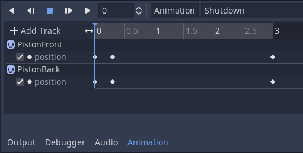

To trigger those functions, we need to connect the `PowerSource`’s `power_updated` signal and the `GUIComponent`’s `gui_status_changed` to the `StirlingEngineEntity`.

Connect both components’ signals to the root node.

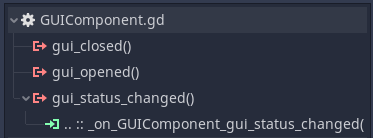

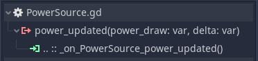

In `/Entities/Entities/StirlingEngineEntity.gd`, we call `_setup_work()` and `_consume_fuel()` through those signal callbacks.

```
func _on_GUIComponent_gui_status_changed() -> void:
    _setup_work()


func _on_PowerSource_power_updated(power_draw, delta) -> void:
    _consume_fuel(delta)
```

The Stirling engine will now wait to receive fuel to refill itself and start to run.

When it runs out of items to consume, it should shut down and reduce the amount of power it’s outputting down to 0.

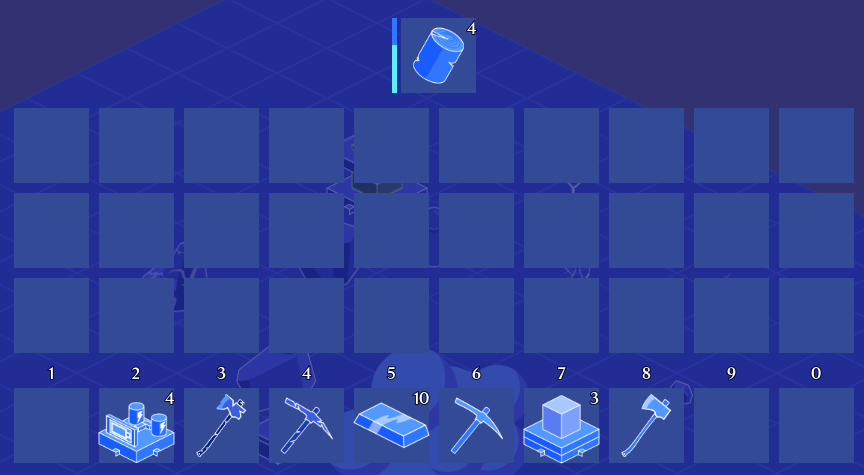

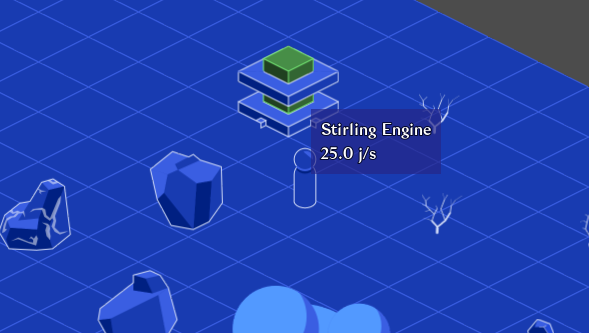

No more breaking the laws of physics! Perpetual motion machines do not exist.

We’re in the home stretch now.

The next and final lessons focus on a new system to automate crafting with machines. I called it the work system as it allows machines to craft items, that is, to do some work for us.

With that, they’ll take that useless ore we can mine and turn it into useful ingots.

To that end, we’ll create two new coal-based and electric furnaces.

## Code reference

Here’s the complete `/Entities/Entities/StirlingEngineEntity.gd` script.

```
extends Entity

const BOOTUP_TIME := 6
const SHUTDOWN_TIME := 3

var available_fuel := 0.0
var last_max_fuel := 0.0

onready var animation_player := $AnimationPlayer
onready var tween := $Tween
onready var shaft := $PistonShaft
onready var power := $PowerSource
onready var gui := $GUIComponent


func get_info() -> String:
    return "%.1f j/s" % power.get_effective_power()


func _update_efficiency(value: float) -> void:
    power.efficiency = value
    Events.emit_signal("info_updated", self)

func _consume_fuel(amount: float) -> void:
    available_fuel = max(available_fuel - amount, 0.0)

    if available_fuel <= 0.0 and gui.gui.fuel:
        last_max_fuel = Recipes.Fuels[Library.get_entity_name_from(gui.gui.fuel)]
        available_fuel = last_max_fuel

        gui.gui.fuel.stack_count -= 1
        if gui.gui.fuel.stack_count == 0:
            gui.gui.fuel.queue_free()
            gui.gui.fuel = null
        else:
            gui.gui.update_labels()
    else:
        _setup_work()

    gui.gui.set_fuel((available_fuel / last_max_fuel) if last_max_fuel > 0.0 else 0.0)


func _setup_work() -> void:
    if not animation_player.is_playing() and (gui.gui.fuel or available_fuel > 0.0):
        animation_player.play("Work")

        tween.interpolate_property(animation_player, "playback_speed", 0, 1, BOOTUP_TIME)
        tween.interpolate_method(self, "_update_efficiency", 0, 1, BOOTUP_TIME)
        tween.interpolate_property(shaft, "modulate", Color.white, Color(0.5, 1, 0.5), BOOTUP_TIME)
        tween.start()

        _consume_fuel(0.0)

    elif (
        animation_player.is_playing()
        and animation_player.current_animation == "Work"
        and not (gui.gui.fuel or available_fuel > 0.0)
    ):
        var work_animation: Animation = animation_player.get_animation(
            animation_player.current_animation
        )
        work_animation.loop = false
        yield(animation_player, "animation_finished")
        work_animation.loop = true

        animation_player.play("Shutdown")
        animation_player.playback_speed = 1.0
        tween.interpolate_property(shaft, "modulate", shaft.modulate, Color(1, 1, 1), SHUTDOWN_TIME)
        tween.interpolate_method(self, "_update_efficiency", 1, 0, SHUTDOWN_TIME)
        tween.start()


func _on_GUIComponent_gui_status_changed() -> void:
    _setup_work()


func _on_PowerSource_power_updated(power_draw, delta) -> void:
    _consume_fuel(delta)
```